# 반도체 기술 심층분석 — HBM 1세대~4세대 기술 진화

Alpha Hunter Tech Deep Dive #2 | 관련 종목: SK하이닉스, 한미반도체, PSK홀딩스, ISC

Author

Alpha Hunter × Chimera AI

Published

May 13, 2026

# 개요: 왜 HBM인가

**핵심 메시지**

**HBM(High Bandwidth Memory)**은 AI 시대의 “메모리 고속도로”다. GPU/가속기가 아무리 빨라도, 메모리 대역폭이 병목이면 성능은 제자리다. HBM은 수천 개의 TSV(Through-Silicon Via)로 DRAM 다이를 수직 적층해 기존 DDR 대비 **10배 이상의 대역폭**을 제공한다. NVIDIA H200, B200부터 차세대 Rubin까지, AI 학습·추론 가속기의 핵심 부품이다.

대규모 언어 모델(LLM)의 파라미터 수가 수조 개를 넘어서면서, GPU의 연산 능력만큼이나 **메모리 대역폭**이 AI 성능을 결정하는 핵심 병목으로 부상했다. HBM은 JEDEC이 2013년 표준을 제정한 이후, 4세대에 걸쳐 대역폭을 128 GB/s에서 2 TB/s 이상으로 **15배** 끌어올렸다. 이 보고서는 HBM의 기술 진화—TSV 미세화, 열설계 혁신, 본딩 기술, 패키징 통합—을 심층 분석하고, 투자 시사점을 도출한다.

# 1 HBM 세대별 기술 진화

## 1.1 세대별 핵심 스펙 비교

Table 1: HBM 세대별 핵심 사양 비교

[output not shown]

## 1.2 기술 진화 타임라인

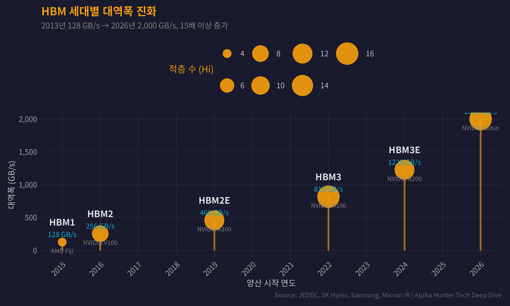

Figure 1: HBM 세대별 기술 진화 타임라인 (2013–2026)

## 1.3 주요 GPU/가속기별 HBM 탑재 현황

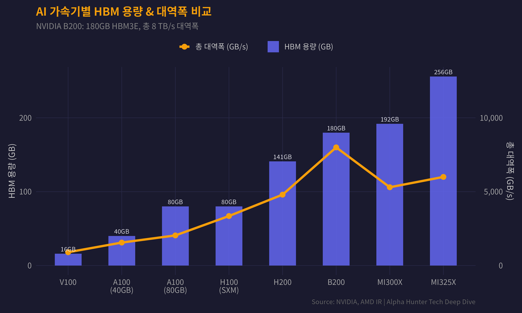

Figure 2: 주요 AI 가속기별 HBM 탑재 용량과 대역폭

# 2 TSV (Through-Silicon Via) 기술

## 2.1 TSV란 무엇인가

TSV(Through-Silicon Via)는 실리콘 다이를 **수직으로 관통하는 미세 구멍**에 구리(Cu)를 채워넣어 상하 다이를 전기적으로 연결하는 기술이다. HBM의 핵심 혁신으로, 기존 와이어 본딩 대비:

- **전기 경로 단축**: 수 mm → 수십 μm, 지연시간 대폭 감소
- **병렬 연결**: 수천 개의 TSV로 1,024~2,048비트 동시 데이터 전송
- **전력 효율**: 짧은 경로로 기생 커패시턴스 감소, 저전압 동작 가능

**TSV 핵심 수치**

- HBM2 기준 **다이당 5,000개 이상**의 TSV 관통
- TSV 직경: 5~10 μm, 종횡비(Aspect Ratio) 10:1~20:1
- HBM4에서는 TSV 수가 **수만 개**로 증가 (2,048비트 I/O)

## 2.2 다이 두께 미세화 트렌드

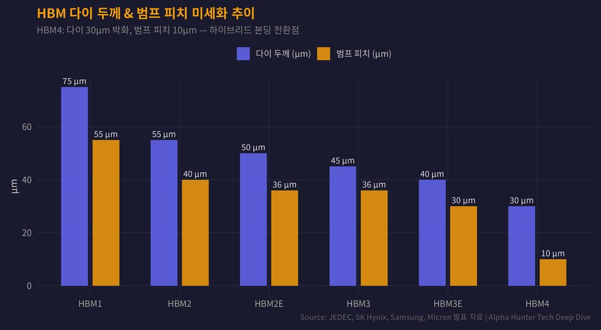

Figure 3: HBM 세대별 다이 두께 및 범프 피치 미세화

# 3 본딩 기술: MR-MUF vs TC-NCF vs 하이브리드

## 3.1 세 가지 본딩 방식 비교

HBM 적층에서 다이를 물리적·전기적으로 접합하는 **본딩(Bonding)** 기술은 수율, 열방출, 비용을 좌우하는 핵심 공정이다.

Table 2: HBM 본딩 기술 비교: MR-MUF vs TC-NCF vs 하이브리드

[output not shown]

**본딩 기술의 투자 시사점**

SK하이닉스의 **MR-MUF**는 현재 HBM 시장 지배의 핵심 무기다. 수율에서 TC-NCF 대비 약 20% 우위를 점하며, 이것이 50% 이상 시장 점유율의 기술적 기반이다. 그러나 **하이브리드 본딩**이 16-Hi 이상 적층에서 필수 기술로 부상하면서, BESI(장비), 삼성(조기 채택) 등이 새로운 수혜주로 떠오르고 있다.

## 3.2 SK하이닉스 MR-MUF 우위의 원천

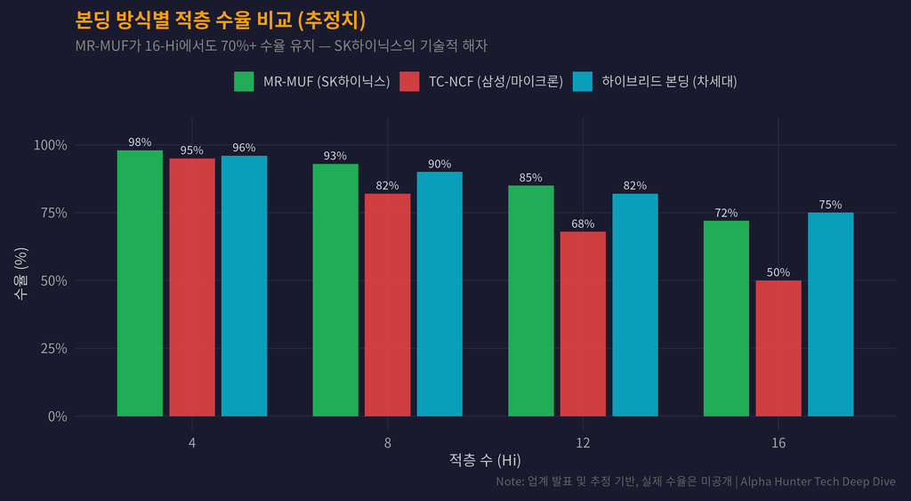

Figure 4: 본딩 방식별 적층 수에 따른 예상 수율 비교

# 4 열설계: HBM의 가장 뜨거운 도전

## 4.1 전력과 열의 벽

HBM 적층이 높아질수록 **열 문제**가 급격히 심각해진다. 16층 적층 시 중간 다이의 열이 빠져나갈 경로가 극히 제한되며, 정션 온도가 85°C를 초과하면 성능 저하(throttling)가 발생한다.

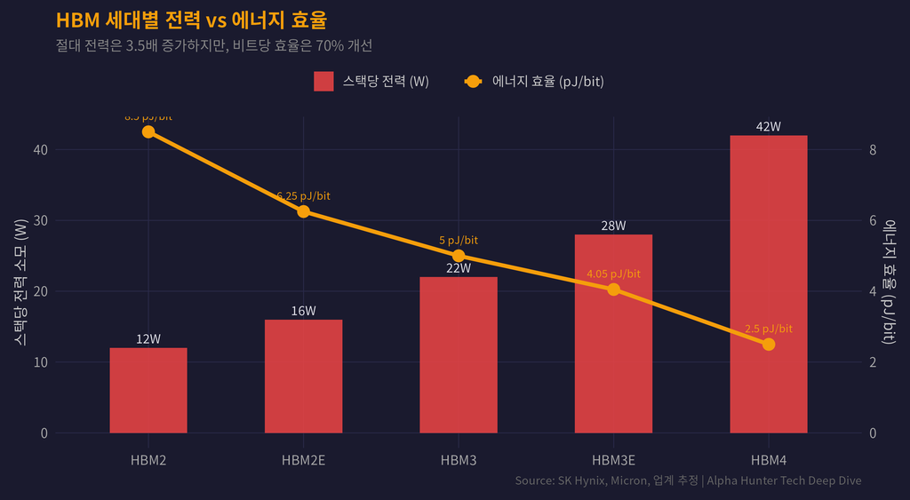

Figure 5: HBM 세대별 전력 소모 및 에너지 효율 변화

## 4.2 열관리 솔루션 기술 구조

**16-Hi 적층의 열 장벽**

HBM4의 16층 적층은 **다이 두께 30μm** × 16 = 총 480μm의 실리콘 탑에서 42W 이상의 열을 방출해야 한다. 중간 다이의 열이 위아래 양쪽으로만 전도되며, 언더필(polymer)의 낮은 열전도율(0.3~0.5 W/mK)이 병목이다.

**현재 개발 중인 열관리 기술:**

1. **Thermal TSV**: 전기적으로 비활성이지만 열 전도용으로 배치되는 구리 기둥. 신호 TSV 사이에 배치하여 수직 열 경로를 확보
2. **고열전도 TIM**: 5 W/mK 이상의 Thermal Interface Material로 다이 간 열 저항 감소
3. **All-around Power TSV**: HBM3E에서 도입된 기술로, TSV 수를 6배 증가시켜 IR Drop 75% 감소
4. **마이크로유체 냉각**: 칩 내부에 미세 채널을 가공해 냉각수를 순환시키는 연구 단계 기술
5. **하이브리드 본딩**: Cu-to-Cu 직접 접촉으로 언더필 열저항을 근본적으로 제거

# 5 HBM4: 패러다임 전환

## 5.1 분리 다이(Split-Die) 아키텍처

HBM4는 HBM 역사상 가장 큰 아키텍처 변화를 가져온다: **베이스 다이(Logic Die)**와 **DRAM 다이의 공정 분리**다.

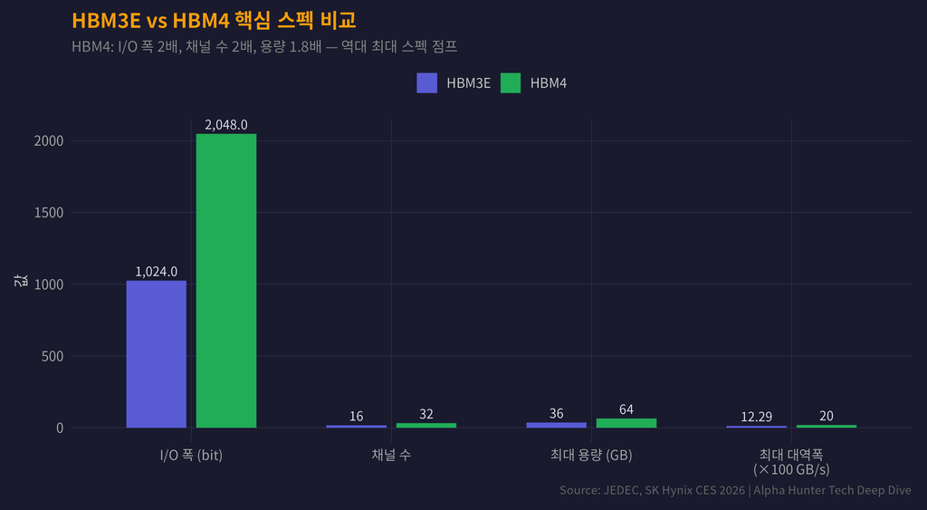

Figure 6: HBM3E vs HBM4 아키텍처 비교 — I/O 폭 및 채널 수

### 5.1.1 HBM4의 핵심 혁신

| 혁신 포인트 | 상세 내용 |
| --- | --- |
| **베이스 다이 로직 공정 분리** | DRAM 다이는 기존 DRAM 공정, 베이스 다이는 TSMC 12nm 로직 공정으로 제조. 최초의 이종 공정 HBM |
| **I/O 폭 2배 확장** | 1,024비트 → 2,048비트, 채널 수 16개 → 32개 |
| **커스터마이징 가능** | 베이스 다이의 컨트롤 로직을 AI 워크로드에 맞춤 설계 가능 |
| **NVIDIA Rubin 플랫폼 최초 탑재** | TSMC N3P 공정 기반 차세대 GPU와 최초 통합 |

## 5.2 HBM4 제조 파트너십

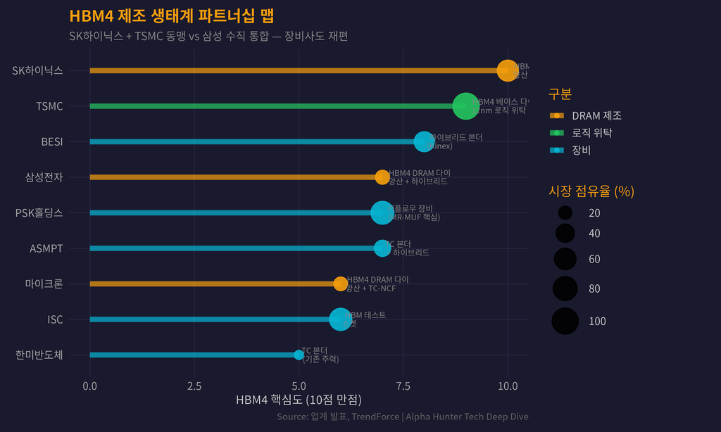

Figure 7: HBM4 제조 생태계: 주요 업체별 역할

# 6 HBM 시장 규모와 경쟁 구도

## 6.1 시장 성장 전망

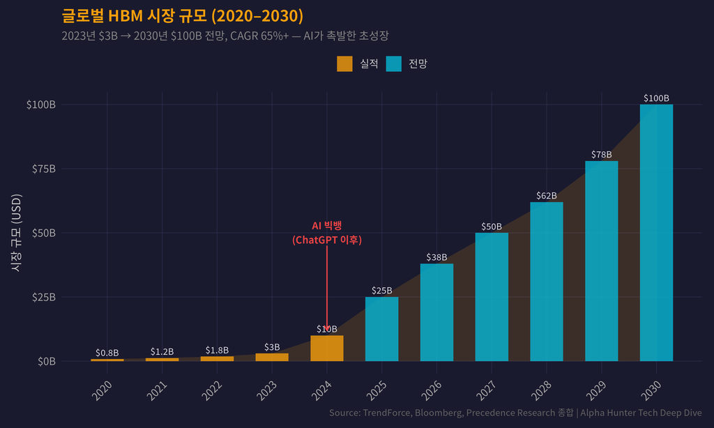

Figure 8: 글로벌 HBM 시장 규모 추이 및 전망 (2020–2030)

## 6.2 시장 점유율 변화

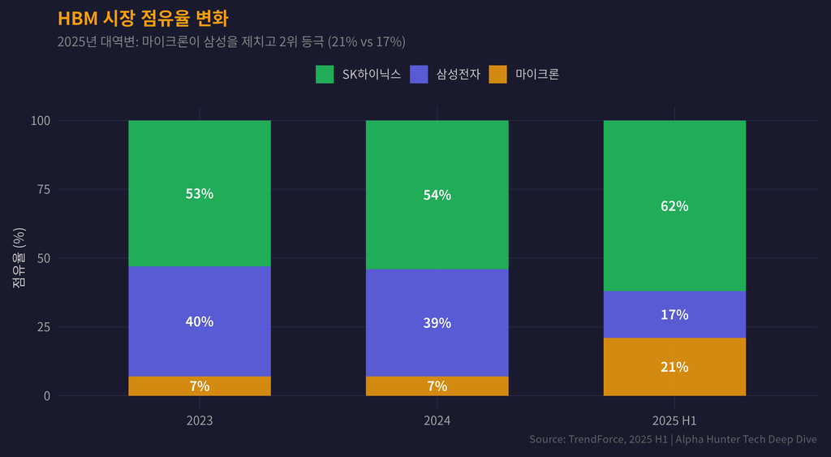

Figure 9: HBM 제조사별 시장 점유율 변화 (2023–2025)

**2025년 대역변: 마이크론의 역습**

2025년 상반기 기준 마이크론(21%)이 삼성(17%)을 제치고 HBM 시장 2위로 부상했다. 마이크론은 HBM3E 12-Hi에서 “경쟁사 대비 30% 낮은 전력”을 무기로 NVIDIA 대량 수주에 성공했다. 삼성은 TC-NCF 수율 문제로 HBM3E 양산이 지연되며 점유율이 급락했다.

# 7 한국 HBM 밸류체인 수혜주

## 7.1 핵심 수혜 기업 분석

Table 3: 한국 HBM 밸류체인 핵심 기업

[output not shown]

**투자 포인트: PSK홀딩스에 주목**

**PSK홀딩스**는 HBM 리플로우 장비 분야에서 **SK하이닉스, 삼성, 마이크론 3사 모두에 납품**하는 유일한 한국 장비사다. MR-MUF 공정의 핵심인 리플로우 장비를 독점적으로 공급하며, HBM 시장 성장이 곧 PSK의 성장으로 직결된다. 2030년 매출 1조 원 목표를 제시했다.

## 7.2 장비 시장 규모 전망

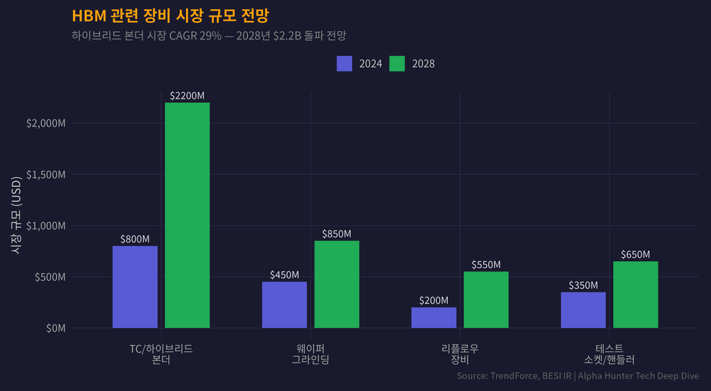

Figure 10: HBM 관련 장비 시장 규모 전망 (2024–2028)

# 8 CoWoS 패키징과 HBM의 통합

## 8.1 CoWoS: AI 칩의 지붕

HBM이 메모리의 “수직 고속도로”라면, **CoWoS(Chip-on-Wafer-on-Substrate)**는 GPU와 HBM을 **수평으로 연결하는 플랫폼**이다. TSMC가 독점 공급하는 이 기술 없이는 HBM을 GPU에 통합할 수 없다.

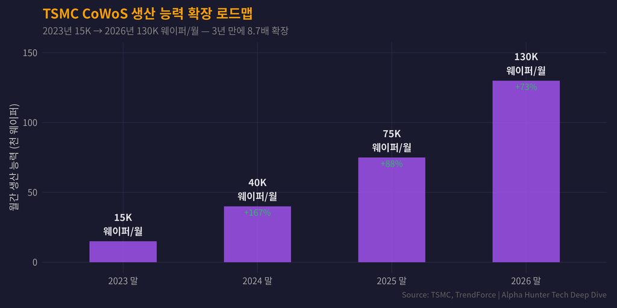

Figure 11: TSMC CoWoS 월간 생산 능력 확장 추이

**CoWoS 로드맵 — 더 커지는 인터포저**

- **현재 (CoWoS-S/R)**: 5.5 레티클 크기, HBM 6~8 스택 통합
- **2027 (CoWoS-L)**: 9.5 레티클, **HBM5 12 스택** 수용
- **2028**: 14 레티클, HBM5 **20 스택** 통합 가능
- CoWoS 기판 핵심 공급사: **Ibiden, Shinko Electric** (일본)

# 9 기술 구조도: HBM 스택의 단면

## 9.1 HBM 적층 구조 개요

```
┌─────────────────────────────────────────────────┐
│                   Heat Spreader                  │  ← 열 방출판
├─────────────────────────────────────────────────┤
│     DRAM Die #16 (30μm)  ─── Core Die           │  ← 최상단 다이
│  ░░░░░░░░░ Micro-bump / Hybrid Bond ░░░░░░░░░░  │
│     DRAM Die #15 (30μm)                          │
│  ░░░░░░░░░░░░░░░░░░░░░░░░░░░░░░░░░░░░░░░░░░░░  │
│              ⋮  (반복)  ⋮                        │
│  ░░░░░░░░░░░░░░░░░░░░░░░░░░░░░░░░░░░░░░░░░░░░  │
│     DRAM Die #2 (30μm)                           │
│  ░░░░░░░░░░░░░░░░░░░░░░░░░░░░░░░░░░░░░░░░░░░░  │
│     DRAM Die #1 (30μm)                           │
│  ████████████████████████████████████████████████│  ← TSV 관통
│     Base Die (Logic) — TSMC 12nm                 │  ← HBM4 혁신: 로직 다이 분리
├─────────────────────────────────────────────────┤
│          Silicon Interposer (CoWoS)              │  ← GPU와 연결
│     │         │          │         │             │
│   [GPU]    [HBM#1]    [HBM#2]   [HBM#N]         │
├─────────────────────────────────────────────────┤
│              Organic Substrate                   │
└─────────────────────────────────────────────────┘
```

**핵심 요소 설명:**

- **DRAM Die**: 24Gb~32Gb 용량의 DRAM 칩. HBM4에서 30μm까지 박화
- **TSV (Through-Silicon Via)**: 각 다이를 수직 관통하는 Cu 전극, 다이당 5,000~수만 개
- **Micro-bump / 하이브리드 본드**: 다이 간 접합. 30μm 피치(HBM3E) → 10μm(HBM4)
- **Base Die**: HBM4에서 분리된 로직 다이. TSMC 12nm 공정, 제어 회로 내장
- **Silicon Interposer**: GPU와 HBM을 연결하는 2.5D 실리콘 기판 (CoWoS)
- **Underfill**: 다이 사이를 채우는 수지. MR-MUF(몰디드 언더필) vs NCF(비전도성 필름)

# 10 투자 시사점

## 10.1 섹터별 수혜 등급

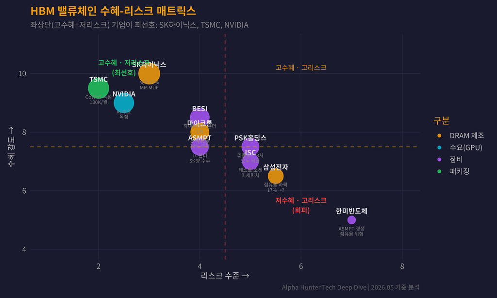

Figure 12: HBM 기술 진화에 따른 밸류체인별 수혜 강도

## 10.2 핵심 투자 결론

**Alpha Hunter 투자 시사점 5가지**

1. **SK하이닉스 (000660)**: HBM 시장 62% 점유, MR-MUF 기술 해자. 2025년 매출 97조 원, HBM 매출 2배 이상 성장. AI 수요 지속 시 **최우선 수혜주**
2. **PSK홀딩스 (031980)**: HBM 리플로우 장비 유일한 3사 동시 납품사. HBM 시장 성장률 = PSK 성장률. 소형주 히든젬 후보
3. **BESI (BESI.AS)**: 하이브리드 본딩 장비 시장의 절대 강자. HBM4 16-Hi 이상에서 하이브리드 본딩이 필수가 되면 **폭발적 성장** 전망
4. **한미반도체 (093240)**: TC 본더 원조이나, ASMPT에 SK하이닉스 물량 이탈 리스크. 특허 분쟁 해소 여부가 관건. **고리스크·고리턴**
5. **마이크론 (MU)**: 전력 효율 30% 우위로 삼성을 제치고 2위 등극. HBM4에서도 경쟁력 유지 시 **재평가 여지** 큼

## 10.3 리스크 요인

- **DRAM 사이클**: HBM도 결국 DRAM이다. 과잉 투자 → 가격 하락 사이클 위험
- **Goldman Sachs 경고**: 2026년 HBM ASP 두 자릿수 하락 가능성 제기
- **중국 제재**: NVIDIA의 중국向 HBM 탑재 제품 수출 규제 강화 시 수요 감소
- **기술 전환 리스크**: 하이브리드 본딩 전환 과정에서 기존 MR-MUF/TC-NCF 장비사의 위상 변동

**면책 문구**

이 프로젝트는 가상 투자 시뮬레이션 목적으로 작성되었습니다. 실제 투자 권유가 아닙니다.

**참고 자료**: JEDEC HBM 표준, SK Hynix / Samsung / Micron IR 자료, TrendForce, Bloomberg, Precedence Research, SemiEngineering, PatSnap, IEEE IEDM 2025, BESI IR